# Experiment 2: summa

### Before Exclusions

**Number of participants tested:**

```
## [1] 150
```

**Participants in each condition:**

```
##
## all_QUD any_QUD  no_QUD
##      50      50      50
```

### Exclusions

**Non-unique participants (remove all attempts):**

```
## [1] 114 115
```

**Participants whose native language is not english:**

```
##   workerid   language
## 1       70
## 2      109 Vietnamese
## 3      131    Spanish
```

**Participants who got at least two practice trials wrong:**

```
##
##  2  3  4
## 17  2  5
```

**Participants who got the audio check wrong more than one once:**

```
## < table of extent 0 >
```

**Participants who got the second comprehension question wrong more than twice:**

```
##
## 23 56
##  1  3
```

**Participants with accuracy of lower than 85% on non-critical trials:**

```
## # A tibble: 8 x 4
## # Groups:   workerid, gaveRightAnswer [8]
##   workerid gaveRightAnswer     n accuracy
##      <int> <chr>           <int>    <dbl>
## 1       25 1                  47     73.4
## 2       50 1                  32     50
## 3       71 1                  50     78.1
## 4       74 1                  52     81.2
## 5       98 1                  37     57.8
## 6      107 1                  54     84.4
## 7      121 1                  53     82.8
## 8      132 1                  40     62.5
```

#### Additional Exclusions

**Participants who gave more than 5 very slow (logRT>20) responses:**

```
## # A tibble: 0 x 3
## # Groups:   workerid [0]
## # … with 3 variables: workerid <int>, slowResponse <lgl>, n <int>
```

**Responses that are very slow (logRT>20)**

```
## [1] 110
```

```
## [1] 3
```

```
## [1] 111
```

## After Exclusions

**Number of participants:**

```
## [1] 111
```

**Participants left in each condition:**

[output not shown]

## General

**Expected number of yes and no answers:**

```
##
##   No  Yes
## 5192 3304
```

**Accuracy**

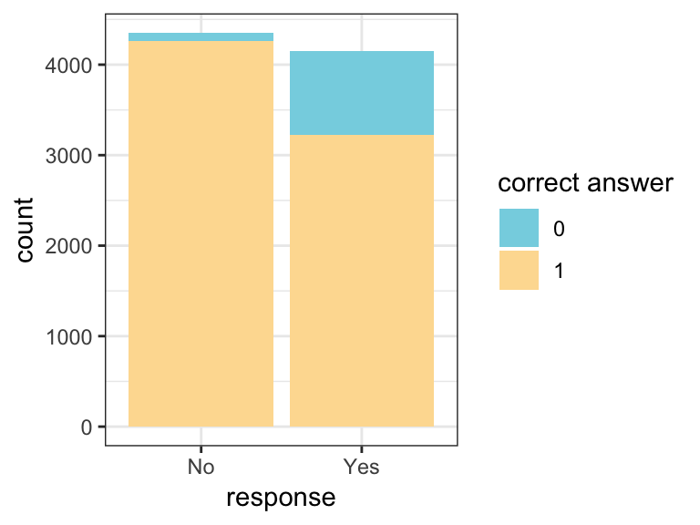

**Accuracy and trial order**

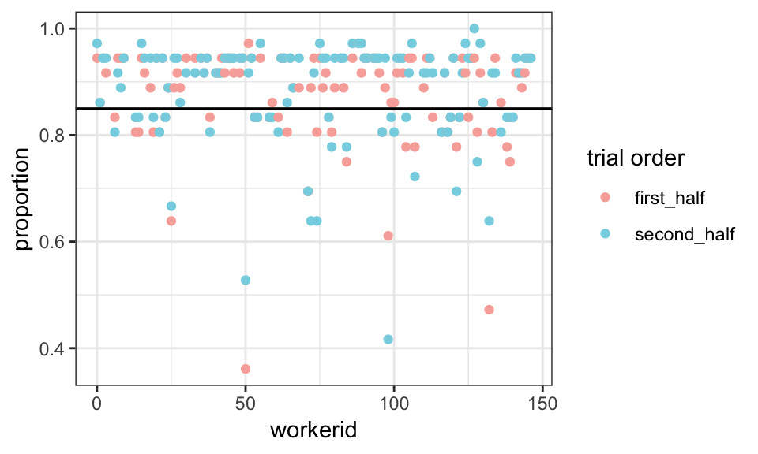

**Distribution of RT and logRT**

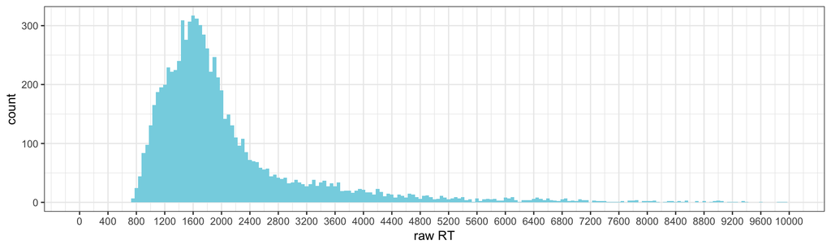

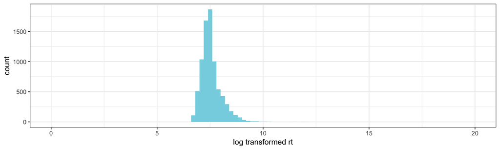

15 fastest responses (raw RT)

```
##  [1] 749 761 762 762 767 772 773 777 777 786 787 797 797 798 801
```

15 slowest responses (raw RT)

```
##  [1]  18571  20420  20699  21136  21460  22898  24191  24239  26063  26384
## [11]  26421  28856  29611 107992 161349
```

### Non-critical Trials

**Response type:**

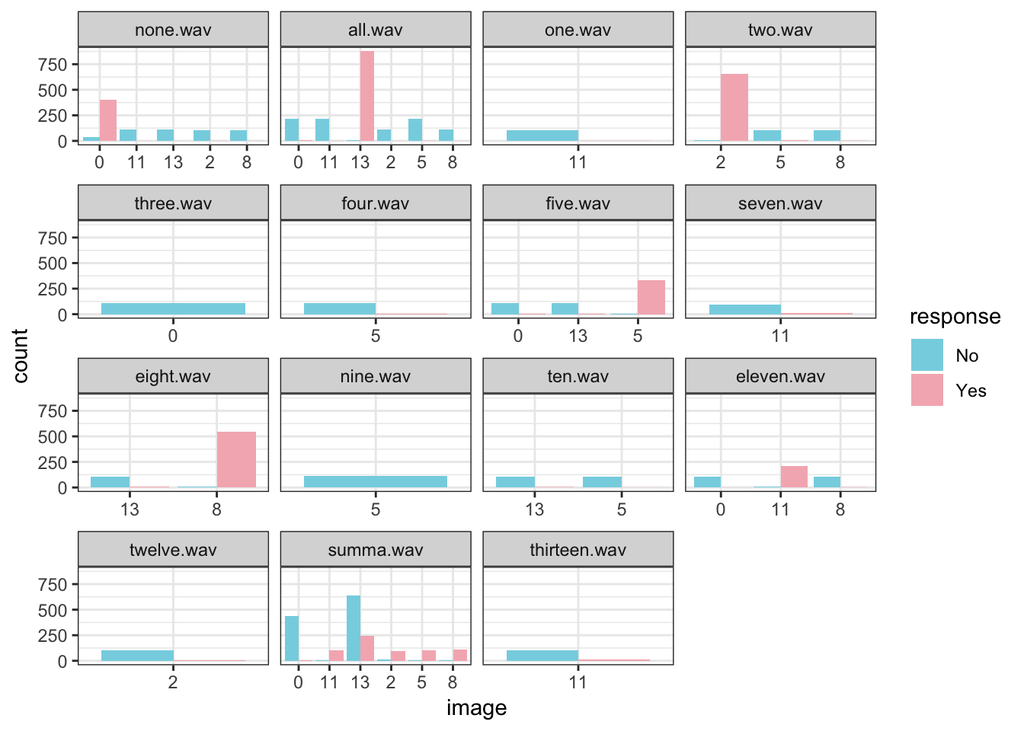

**Response time:**

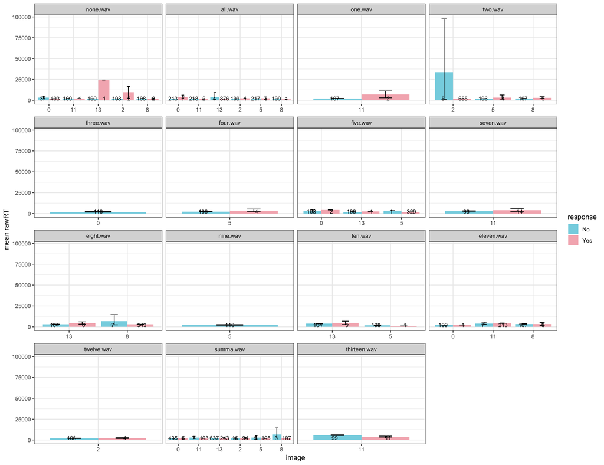

### Critical Trials

```
## [1] 0
```

#### Response Type

[figure not shown]

**Distribution of participants over number of semantic responses**

```
## < table of extent 0 x 0 >
```

[figure not shown]

**Response type and trial order**

[figure not shown]

**Age distribution of participants**

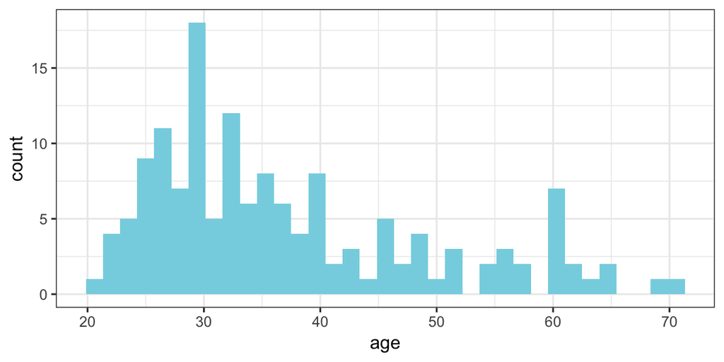

**Response type and age**

[figure not shown]

#### Response Time

**Distribution of response times in critical trials**

[figure not shown]

**Response time and QUD**

[figure not shown]

**Response time, trial order and QUD**

[figure not shown]

**Response time, responder type and QUD**

[figure not shown]

**Response time, age and QUD**

[figure not shown]

**Response time, age, responder type and QUD**

[figure not shown]